# DDP-Shiny Weather App

Maciej Nasinski

November 12, 2016

# Introduction

During the Coursera Data Science course (Developing Data Products) it was built a Shiny application. This application shows a spectrum of weather conditions across the world. Another objective was to give a possibility to predict a future weather conditions. Database was built using [WunderGround](https://www.wunderground.com). It is important to state that the application is made for educational purpose and the data should not be use for commercial purpose. There was taken into account a continent location and a Hemisphere during selecting Cities for Database. From a wide palette of weather indicators there was chosen only 4 of them:

- Mean Temperature Celsius
- Mean Humidity
- Mean Pressure h-Pa
- Mean Wind Speed Km-h

It should be surprising that there is not indicator for raining. The decision was taken because of high unpredictable of raining and lack of records for this indicator.

# Prediction Functionality

The Main functionality of the app is to assess predictions of 4 most important indicators. A prediction is calculated by functions from forecast package. In most cases a significant seasonality gives chance for building valuable prediction.  
Example for MeanHumidity Berlin:

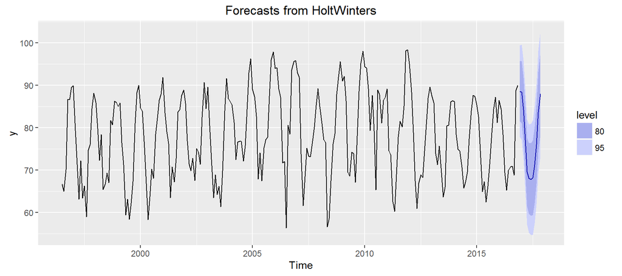

```r
Holt = HoltWinters(na.approx(ts(unlist(datas_pred[,'MeanHumidity_Berlin']),frequency = 12,start=c(1996,1),end=c(2016,11))))
autoplot(forecast(Holt,h=12))
```

# Weather Conditions during Year - Plots

Many people are interested in Weather conditions across the world. The main aim is to show the difference in a clear manner. Thus it was used a one frame plot of average values of last 20 records - during the year (week interval). There is produced a static plot for a certain indicator and city.  
Example for MeanHumidity Berlin:

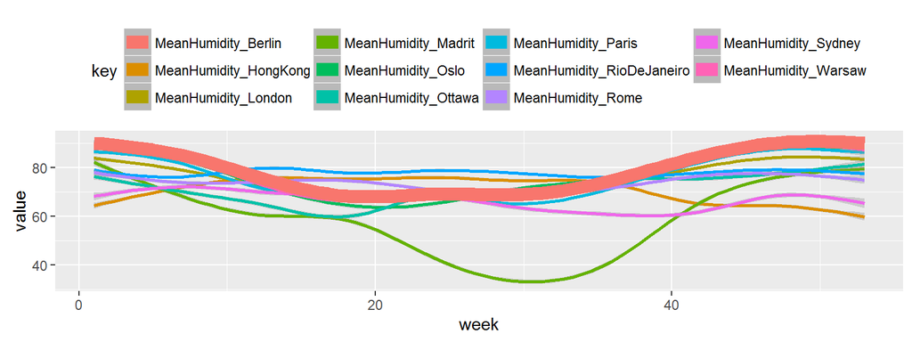

```r
data_temporary = tempsg %>% as.data.frame() %>% slice(grep("MeanHumidity_Berlin", tempsg$key)) %>%
  na.omit()
ggplot(tempsg,aes(x=week,y=value,color=key))+ geom_smooth(size=1)+
  geom_smooth(data=data_temporary,aes(x=week,y=value,color=key),size=4)+
  theme(legend.position="top")
```

# Further possibilities to develop app.

Current app is sufficient but far from being final product. The main aim will be to build real-time downloading of a certain city. Process of downloading data spread waiting time but new functionality probably worth it.

# End

Thank you for your time.

[Application](https://polkas.shinyapps.io/ShinyAppWeather/)

[Source Code](https://github.com/Polkas/ShinyWeatherApp)